```r
options(OutDec = ".")  # Asegurar punto decimal en este chunk

# Establecer semilla aleatoria
set.seed(sample(1:10000, 1))

# Aleatorización del contexto del problema
contextos <- c(
  "empresa", "organización", "compañía", "institución", "corporación",
  "entidad", "firma", "negocio", "sociedad", "grupo empresarial"
)
contexto <- sample(contextos, 1)

# Aleatorización de los tipos de bienes
tipos_bien1 <- c("carro", "auto", "vehículo", "automóvil", "coche")
tipos_bien2 <- c("casa", "vivienda", "residencia", "hogar", "domicilio")
tipos_bien3 <- c("apartamento", "departamento", "piso", "condominio")

bien1 <- sample(tipos_bien1, 1)
bien2 <- sample(tipos_bien2, 1)
bien3 <- sample(tipos_bien3, 1)

# Aleatorización de términos para el enunciado
terminos_encuesta <- c("encuesta", "sondeo", "estudio", "investigación", "consulta")
termino_encuesta <- sample(terminos_encuesta, 1)

terminos_personas <- c("personas", "empleados", "trabajadores", "colaboradores", "miembros")
termino_personas <- sample(terminos_personas, 1)

terminos_bienes <- c("bienes", "posesiones", "propiedades", "activos", "patrimonios")
termino_bienes <- sample(terminos_bienes, 1)

terminos_resultados <- c("resultados", "datos", "estadísticas", "cifras")
termino_resultados <- sample(terminos_resultados, 1)

# Aleatorización de colores para el gráfico circular (paletas oscuras)
paleta_colores <- list(
  c("#C62828", "#2E7D32", "#1565C0", "#EF6C00", "#6A1B9A"),  # Paleta oscura 1
  c("#D32F2F", "#388E3C", "#1976D2", "#F57C00", "#7B1FA2"),  # Paleta saturada
  c("#B71C1C", "#1B5E20", "#0D47A1", "#E65100", "#4A148C"),  # Paleta oscura 2
  c("#AD1457", "#00695C", "#283593", "#FF6F00", "#4A148C"),  # Paleta oscura 3
  c("#880E4F", "#1B5E20", "#0D47A1", "#BF360C", "#4A148C")   # Paleta oscura 4
)
paleta_seleccionada <- sample(paleta_colores, 1)[[1]]

# Aleatorización de los porcentajes manteniendo coherencia matemática
# Generación de porcentajes iniciales para cada categoría
set_porcentajes <- function() {
  repeat {
    # Generar valores base aleatorios
    p_bien1_bien3 <- sample(15:35, 1)  # Porcentaje de bien1 y bien3
    p_solo_bien3 <- sample(15:30, 1)   # Porcentaje solo bien3
    p_solo_bien2 <- sample(25:40, 1)   # Porcentaje solo bien2
    p_solo_bien1 <- sample(5:10, 1)    # Porcentaje solo bien1

    # Calcular el porcentaje restante para bien1 y bien2
    p_bien1_bien2 <- 100 - (p_bien1_bien3 + p_solo_bien3 + p_solo_bien2 + p_solo_bien1)

    # Validar que el porcentaje restante sea positivo y razonable
    if (p_bien1_bien2 >= 10 && p_bien1_bien2 <= 25) {
      return(c(p_bien1_bien3, p_solo_bien3, p_solo_bien2, p_solo_bien1, p_bien1_bien2))
    }
  }
}

# Obtener porcentajes válidos
porcentajes_base <- set_porcentajes()

p_bien1_bien3 <- porcentajes_base[1]  # Porcentaje de bien1 y bien3
p_solo_bien3 <- porcentajes_base[2]   # Porcentaje solo bien3
p_solo_bien2 <- porcentajes_base[3]   # Porcentaje solo bien2
p_solo_bien1 <- porcentajes_base[4]   # Porcentaje solo bien1
p_bien1_bien2 <- porcentajes_base[5]  # Porcentaje de bien1 y bien2

# Guardar los porcentajes originales para visualización
porcentajes_grafico <- c(p_bien1_bien3, p_solo_bien3, p_solo_bien2, p_solo_bien1, p_bien1_bien2)

# Verificar que suman 100%
test_that("Los porcentajes suman 100%", {
  expect_equal(sum(porcentajes_base), 100)
})
```

Test passed 🥇

```r
# ENFOQUE MEJORADO: Primero determinamos el total y luego las categorías sin redondear
# Número total de personas - elegimos un número que sea divisible por 100 para evitar errores de redondeo
total_personas <- sample(c(500, 600, 700, 800, 900, 1000, 1200, 1500, 2000), 1)

# Calculamos la cantidad exacta de personas para cada categoría (sin redondeo)
# Usamos división por enteros para evitar problemas decimales
personas_exactas <- list(
  bien1_bien3 = (total_personas * p_bien1_bien3) %/% 100,
  solo_bien3 = (total_personas * p_solo_bien3) %/% 100,
  solo_bien2 = (total_personas * p_solo_bien2) %/% 100,
  solo_bien1 = (total_personas * p_solo_bien1) %/% 100,
  bien1_bien2 = (total_personas * p_bien1_bien2) %/% 100
)

# Calculamos el residuo (personas no asignadas por la división entera)
personas_no_asignadas <- total_personas - sum(unlist(personas_exactas))

# Distribuimos las personas no asignadas a las categorías en orden
# hasta completar exactamente el total
if (personas_no_asignadas > 0) {
  categorias <- c("bien1_bien3", "solo_bien3", "solo_bien2", "solo_bien1", "bien1_bien2")
  for (i in 1:personas_no_asignadas) {
    idx <- ((i-1) %% 5) + 1  # Cicla entre 1 y 5
    personas_exactas[[categorias[idx]]] <- personas_exactas[[categorias[idx]]] + 1
  }
}

# Asignamos los valores finales de personas por categoría
personas_bien1_bien3 <- personas_exactas$bien1_bien3
personas_solo_bien3 <- personas_exactas$solo_bien3
personas_solo_bien2 <- personas_exactas$solo_bien2
personas_solo_bien1 <- personas_exactas$solo_bien1
personas_bien1_bien2 <- personas_exactas$bien1_bien2

# Verificamos que la suma sea exactamente igual al total
personas <- c(personas_bien1_bien3, personas_solo_bien3, personas_solo_bien2,
              personas_solo_bien1, personas_bien1_bien2)
test_that("La suma de todas las categorías es igual al total", {
  expect_equal(sum(personas), total_personas)
})
```

Test passed 🎉

```r
# Recalculamos los porcentajes exactos basados en las cantidades finales de personas
# Estos son los porcentajes que usaremos para todos los cálculos en la solución
porcentajes_exactos <- list(
  bien1_bien3 = (personas_bien1_bien3 * 100) / total_personas,
  solo_bien3 = (personas_solo_bien3 * 100) / total_personas,
  solo_bien2 = (personas_solo_bien2 * 100) / total_personas,
  solo_bien1 = (personas_solo_bien1 * 100) / total_personas,
  bien1_bien2 = (personas_bien1_bien2 * 100) / total_personas
)

# Y los porcentajes redondeados para mostrar en pantalla
porcentajes_mostrar <- list(
  bien1_bien3 = round(porcentajes_exactos$bien1_bien3),
  solo_bien3 = round(porcentajes_exactos$solo_bien3),
  solo_bien2 = round(porcentajes_exactos$solo_bien2),
  solo_bien1 = round(porcentajes_exactos$solo_bien1),
  bien1_bien2 = round(porcentajes_exactos$bien1_bien2)
)

# Verificamos que el total de los porcentajes exactos sea 100%
test_that("Los porcentajes exactos suman 100%", {
  expect_true(abs(sum(unlist(porcentajes_exactos)) - 100) < 0.001)
})
```

Test passed 🥇

```r
# Para visualización y verificación
cat("Total de personas:", total_personas, "\n")
```

Total de personas: 700

```r
cat("Distribución por categoría:\n")
```

Distribución por categoría:

```r
cat("- bien1_bien3:", personas_bien1_bien3, "personas,",
    porcentajes_exactos$bien1_bien3, "% (exacto),",
    porcentajes_mostrar$bien1_bien3, "% (mostrado)\n")
```

- bien1_bien3: 196 personas, 28 % (exacto), 28 % (mostrado)

```r
cat("- solo_bien3:", personas_solo_bien3, "personas,",
    porcentajes_exactos$solo_bien3, "% (exacto),",
    porcentajes_mostrar$solo_bien3, "% (mostrado)\n")
```

- solo_bien3: 119 personas, 17 % (exacto), 17 % (mostrado)

```r
cat("- solo_bien2:", personas_solo_bien2, "personas,",
    porcentajes_exactos$solo_bien2, "% (exacto),",
    porcentajes_mostrar$solo_bien2, "% (mostrado)\n")
```

- solo_bien2: 182 personas, 26 % (exacto), 26 % (mostrado)

```r
cat("- solo_bien1:", personas_solo_bien1, "personas,",
    porcentajes_exactos$solo_bien1, "% (exacto),",
    porcentajes_mostrar$solo_bien1, "% (mostrado)\n")
```

- solo_bien1: 49 personas, 7 % (exacto), 7 % (mostrado)

```r
cat("- bien1_bien2:", personas_bien1_bien2, "personas,",
    porcentajes_exactos$bien1_bien2, "% (exacto),",
    porcentajes_mostrar$bien1_bien2, "% (mostrado)\n")
```

- bien1_bien2: 154 personas, 22 % (exacto), 22 % (mostrado)

```r
# Mapa de datos para acceso uniforme a todas las categorías
datos_categorias <- list(
  solo_bien1 = list(
    personas = personas_solo_bien1,
    texto = paste0("solo ", bien1),
    porcentaje_exacto = porcentajes_exactos$solo_bien1,
    porcentaje_mostrar = porcentajes_mostrar$solo_bien1
  ),
  solo_bien2 = list(
    personas = personas_solo_bien2,
    texto = paste0("solo ", bien2),
    porcentaje_exacto = porcentajes_exactos$solo_bien2,
    porcentaje_mostrar = porcentajes_mostrar$solo_bien2
  ),
  solo_bien3 = list(
    personas = personas_solo_bien3,
    texto = paste0("solo ", bien3),
    porcentaje_exacto = porcentajes_exactos$solo_bien3,
    porcentaje_mostrar = porcentajes_mostrar$solo_bien3
  ),
  bien1_bien2 = list(
    personas = personas_bien1_bien2,
    texto = paste0(bien1, " y ", bien2),
    porcentaje_exacto = porcentajes_exactos$bien1_bien2,
    porcentaje_mostrar = porcentajes_mostrar$bien1_bien2
  ),
  bien1_bien3 = list(
    personas = personas_bien1_bien3,
    texto = paste0(bien1, " y ", bien3),
    porcentaje_exacto = porcentajes_exactos$bien1_bien3,
    porcentaje_mostrar = porcentajes_mostrar$bien1_bien3
  )
)

# Seleccionar un valor conocido para el enunciado
tipos_condicion <- c("bien1_bien3", "solo_bien3", "solo_bien2", "solo_bien1", "bien1_bien2")
tipo_condicion <- sample(tipos_condicion, 1)

# Determinar el valor y texto de la condición inicial
valor_condicion <- datos_categorias[[tipo_condicion]]$personas
texto_condicion <- datos_categorias[[tipo_condicion]]$texto
porcentaje_condicion_exacto <- datos_categorias[[tipo_condicion]]$porcentaje_exacto
porcentaje_condicion_mostrar <- datos_categorias[[tipo_condicion]]$porcentaje_mostrar

# Aleatorización para las preguntas en formato cloze
# Pregunta 1: Cuántas personas poseen un bien específico
# Excluimos el tipo_condicion para evitar preguntas redundantes
bienes_pregunta1 <- c("solo_bien1", "solo_bien2", "solo_bien3", "bien1_bien2", "bien1_bien3")
bienes_pregunta1 <- bienes_pregunta1[bienes_pregunta1 != tipo_condicion]
tipo_pregunta1 <- sample(bienes_pregunta1, 1)

# Determinar el texto y la respuesta para la pregunta 1
respuesta1 <- datos_categorias[[tipo_pregunta1]]$personas
texto_pregunta1 <- datos_categorias[[tipo_pregunta1]]$texto
porcentaje_pregunta1_exacto <- datos_categorias[[tipo_pregunta1]]$porcentaje_exacto
porcentaje_pregunta1_mostrar <- datos_categorias[[tipo_pregunta1]]$porcentaje_mostrar

# Pregunta 2: Probabilidad de tener un bien específico
# Excluimos tanto tipo_condicion como tipo_pregunta1 para evitar redundancias
bienes_pregunta2 <- c("solo_bien1", "solo_bien2", "solo_bien3", "bien1_bien2", "bien1_bien3")
bienes_pregunta2 <- bienes_pregunta2[!(bienes_pregunta2 %in% c(tipo_condicion, tipo_pregunta1))]
tipo_pregunta2 <- sample(bienes_pregunta2, 1)

# Determinar el texto y la respuesta para la pregunta 2
texto_pregunta2 <- datos_categorias[[tipo_pregunta2]]$texto
# Calculamos la probabilidad exacta como la proporción de personas
probabilidad_exacta <- datos_categorias[[tipo_pregunta2]]$personas / total_personas
# Redondeamos a 4 cifras significativas para cálculos internos
respuesta2 <- signif(probabilidad_exacta, 4)

# Pregunta 3: Total de personas encuestadas
respuesta3 <- total_personas
```

```r
options(OutDec = ".")  # Asegurar punto decimal en este chunk

# Aleatorizar estilos visuales adicionales para el gráfico
estilo_grafico <- list(
  # Aleatorizar el ángulo de inicio
  angulo_inicio = sample(c(0, 45, 90, 135, 180, 225, 270, 315), 1),

  # Aleatorizar el estilo de borde
  borde = sample(list(
    list(color = "white", grosor = 1),
    list(color = "white", grosor = 1.5),
    list(color = "#DDDDDD", grosor = 1),
    list(color = "#333333", grosor = 0.5),
    list(color = "none", grosor = 0)
  ), 1)[[1]],

  # Aleatorizar el estilo de sombra
  sombra = sample(c(TRUE, FALSE), 1, prob = c(0.7, 0.3)),

  # Aleatorizar el estilo de etiquetas de porcentaje
  estilo_porcentaje = sample(list(
    list(color_fondo = "black", alpha = 0.7, estilo = "round", padding = 0.2),
    list(color_fondo = "#333333", alpha = 0.8, estilo = "round", padding = 0.3),
    list(color_fondo = "#555555", alpha = 0.7, estilo = "round,pad=0.2", padding = 0.2),
    list(color_fondo = "none", alpha = 1, estilo = "round", padding = 0)
  ), 1)[[1]],

  # Aleatorizar el estilo de las etiquetas externas
  estilo_etiquetas = sample(list(
    list(color_fondo = "white", color_borde = "gray", alpha = 0.9, estilo = "round", padding = 0.3),
    list(color_fondo = "white", color_borde = "#AAAAAA", alpha = 0.95, estilo = "round", padding = 0.4),
    list(color_fondo = "#F5F5F5", color_borde = "#CCCCCC", alpha = 0.9, estilo = "round", padding = 0.3),
    list(color_fondo = "#EEEEEE", color_borde = "#999999", alpha = 0.9, estilo = "round", padding = 0.3)
  ), 1)[[1]],

  # Aleatorizar el sector destacado (explode)
  sector_destacado = sample(0:4, 1)
)

# Código Python para generar el gráfico circular
codigo_python <- paste0("
import matplotlib
matplotlib.use('Agg')  # Usar backend no interactivo
import matplotlib.pyplot as plt
import numpy as np

# Datos para el gráfico - usamos los porcentajes para mostrar que se calcularon para asegurar coherencia
labels = ['", bien1, " y ", bien3, "', 'Solo ", bien3, "', 'Solo ", bien2, "',
          'Solo ", bien1, "', '", bien1, " y ", bien2, "']

# Usamos porcentajes_mostrar para asegurar coherencia visual con los cálculos
sizes = [", porcentajes_mostrar$bien1_bien3, ", ", porcentajes_mostrar$solo_bien3, ", ", porcentajes_mostrar$solo_bien2, ",
         ", porcentajes_mostrar$solo_bien1, ", ", porcentajes_mostrar$bien1_bien2, "]

colors = ['", paleta_seleccionada[1], "', '", paleta_seleccionada[2], "',
          '", paleta_seleccionada[3], "', '", paleta_seleccionada[4], "',
          '", paleta_seleccionada[5], "']

# Crear explode para destacar un sector específico
explode = [0, 0, 0, 0, 0]
explode[", estilo_grafico$sector_destacado, "] = 0.03  # Destacar el sector seleccionado

# Crear figura con más espacio para acomodar las etiquetas externas
plt.figure(figsize=(7, 6))  # Aumentar tamaño para dar espacio a las etiquetas

# Crear gráfico circular con estilos personalizados
wedges, texts, autotexts = plt.pie(
    sizes,
    explode=explode,
    colors=colors,
    shadow=", ifelse(estilo_grafico$sombra, "True", "False"), ",
    startangle=", estilo_grafico$angulo_inicio, ",  # Ángulo de inicio aleatorizado
    autopct='%d%%',  # Siempre mostrar porcentajes enteros para evitar confusiones
    pctdistance=0.75,  # Ubicar porcentajes más cerca del borde exterior
    wedgeprops={'edgecolor': '", estilo_grafico$borde$color, "', 'linewidth': ", estilo_grafico$borde$grosor, "},
    textprops={'fontsize': 10, 'fontweight': 'bold', 'color': 'white'}
)

# Configuración estética de los textos de porcentaje con recuadros
for autotext in autotexts:
    autotext.set_fontsize(9)  # Tamaño de fuente para porcentajes
    autotext.set_weight('bold')
    # Crear un recuadro semitransparente para los porcentajes
", if(estilo_grafico$estilo_porcentaje$color_fondo != "none") paste0("    bbox_props = {'boxstyle': '", estilo_grafico$estilo_porcentaje$estilo, "',
                 'facecolor': '", estilo_grafico$estilo_porcentaje$color_fondo, "',
                 'alpha': ", estilo_grafico$estilo_porcentaje$alpha, ",
                 'edgecolor': 'none'}
    autotext.set_bbox(bbox_props)"), "

# Eliminar los textos del pie (los reemplazaremos con etiquetas externas)
for text in texts:
    text.set_visible(False)

# Crear etiquetas externas con líneas conectoras
bbox_props = {'boxstyle': '", estilo_grafico$estilo_etiquetas$estilo, "',
             'facecolor': '", estilo_grafico$estilo_etiquetas$color_fondo, "',
             'edgecolor': '", estilo_grafico$estilo_etiquetas$color_borde, "',
             'alpha': ", estilo_grafico$estilo_etiquetas$alpha, "}

# Calcular posiciones de etiquetas externas optimizadas para evitar solapamiento
def get_label_position(angle_rad, wedge_size):
    # Ajustar distancia basada en el tamaño del sector
    # Sectores más pequeños tienen etiquetas más alejadas para evitar solapamiento
    distance_factor = 1.25 if wedge_size < 15 else 1.15

    # Determinar coordenadas
    x = distance_factor * np.cos(angle_rad)
    y = distance_factor * np.sin(angle_rad)

    # Ajustar alineación basada en cuadrante
    if x < 0:
        ha = 'right'
    else:
        ha = 'left'

    if y < 0:
        va = 'top'
    else:
        va = 'bottom'

    # Para sectores muy pequeños, ajustar más la posición para evitar solapamiento
    if wedge_size < 10:
        x *= 1.1
        y *= 1.1

    return x, y, ha, va

# Variables de Python (no podemos acceder a las variables de R directamente)
# Añadimos un marcador de categoría simple
labels_with_info = [
    f'{labels[0]} (categoría 1)',
    f'{labels[1]} (categoría 2)',
    f'{labels[2]} (categoría 3)',
    f'{labels[3]} (categoría 4)',
    f'{labels[4]} (categoría 5)'
]

# Colocar etiquetas externas con líneas conectoras
for i, wedge in enumerate(wedges):
    # Calcular ángulo medio del sector
    ang = (wedge.theta1 + wedge.theta2) / 2
    ang_rad = np.radians(ang)

    # Calcular coordenadas para el inicio de la línea conectora (en el borde del sector)
    # El factor 0.85 asegura que la línea empiece cerca del borde del sector
    x_edge = 0.85 * np.cos(ang_rad)
    y_edge = 0.85 * np.sin(ang_rad)

    # Obtener posición optimizada para la etiqueta
    x_label, y_label, ha, va = get_label_position(ang_rad, sizes[i])

    # Dibujar línea conectora
    con = plt.annotate('',
                      xy=(x_edge, y_edge),  # Inicio (en el borde del sector)
                      xytext=(x_label * 0.95, y_label * 0.95),  # Fin (cerca de la etiqueta)
                      arrowprops=dict(arrowstyle='-', color='", estilo_grafico$estilo_etiquetas$color_borde, "', lw=0.8))

    # Añadir etiqueta con recuadro personalizado - mostramos solo el texto básico sin el conteo
    plt.text(x_label, y_label, labels[i],
            fontsize=8,
            fontweight='bold',
            ha=ha,
            va=va,
            bbox=bbox_props,
            zorder=10)

# Asegurar que el gráfico sea un círculo
plt.axis('equal')

# Añadir título en la parte inferior del gráfico
plt.figtext(0.5, 0.01,  # Posición x=0.5 (centro), y=0.01 (parte inferior)
           'Distribución de bienes (total: ", total_personas, " personas)',
           fontsize=12,
           fontweight='bold',
           color='#333333',
           ha='center')  # Alineación horizontal centrada

# Ajustar los márgenes para dejar espacio a las etiquetas externas
plt.tight_layout(pad=1.5, rect=[0, 0.05, 1, 0.95])  # Ajustar rect para dar más espacio

# Guardar en múltiples formatos para asegurar compatibilidad
plt.savefig('grafico_circular.png', dpi=150, bbox_inches='tight',
           transparent=True, format='png')
plt.savefig('grafico_circular.pdf', dpi=150, bbox_inches='tight',
           transparent=True, format='pdf')
plt.close()
")

# Ejecutar código Python para generar la figura
py_run_string(codigo_python)
```

# Question

En La Tebaida se realizó un(a) encuesta a un grupo de trabajadores de un(a) entidad sobre el tipo de propiedades que poseen. Los(las) estadísticas se presentan en la gráfica.

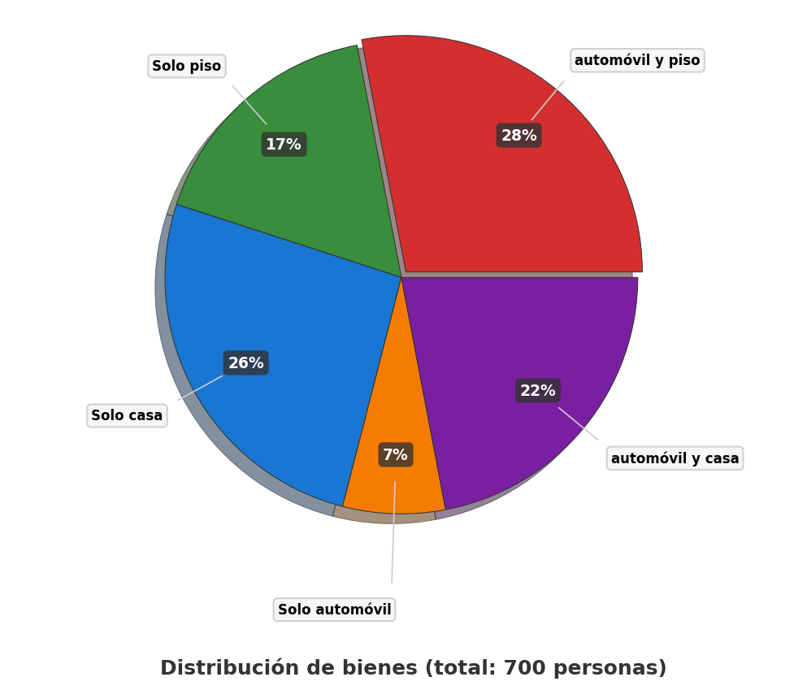

## Answerlist

- Según el gráfico, si 49 trabajadores de la entidad poseen solo automóvil, ¿cuántos trabajadores poseen automóvil y casa?
- Si se escoge una persona del grupo al azar, ¿cuál es la probabilidad de que tenga solo casa? (Exprese la respuesta como un número decimal con 4 decimales, por ejemplo: 0.2500)
- ¿Cuántas personas de la entidad fueron encuestadas en total?

# Solution

Para resolver este problema, necesitamos analizar la información proporcionada en el gráfico circular y aplicar conceptos de proporcionalidad y probabilidad.

### Pregunta 1: Número de personas que poseen automóvil y casa

Sabemos que 49 trabajadores poseen solo automóvil, lo que representa el 7% del total según el gráfico.

Para calcular el total de personas:

```
Total = (valor_conocido × 100%) ÷ porcentaje_conocido
Total = (49 × 100%) ÷ 7%
Total = (49 × 100) ÷ 7
Total = 4900 ÷ 7
Total = 700.0000
Total = 700 trabajadores
```

Ahora podemos calcular cuántas personas poseen automóvil y casa:

- Según el gráfico, las personas con automóvil y casa representan el 22% del total.

```
Número de personas = (porcentaje_buscado × total_personas) ÷ 100%
Número de personas = (22% × 700) ÷ 100%
Número de personas = (22 × 700) ÷ 100
Número de personas = 15400 ÷ 100
Número de personas = 154.0000
Número de personas = 154 trabajadores
```

### Pregunta 2: Probabilidad de que una persona tenga solo casa

La probabilidad se calcula dividiendo el número de casos favorables entre el número total de casos posibles:

- Número de personas con solo casa = 182 trabajadores
- Total de personas = 700 trabajadores
- Probabilidad = 182 ÷ 700
- Probabilidad = 0.2600

### Pregunta 3: Total de personas encuestadas en la entidad

Como calculamos en la primera pregunta, el total de personas encuestadas en la entidad es 700 trabajadores.

Verificación de la coherencia de datos: * automóvil y piso: 196 trabajadores (28% del total) * Solo piso: 119 trabajadores (17% del total) * Solo casa: 182 trabajadores (26% del total) * Solo automóvil: 49 trabajadores (7% del total) * automóvil y casa: 154 trabajadores (22% del total)

La suma de todas estas categorías es 700 trabajadores, que coincide exactamente con nuestro total calculado de 700 trabajadores.

## Answerlist

- La respuesta es 154.
- La respuesta es 0.26.
- La respuesta es 700.

# Meta-information

exname: proporciones_diagrama_circular extype: cloze exclozetype: num|num|num exsolution: 154|0.26|700 extol: 0|0.0001|0 exsection: Estadística|Proporciones|Interpretación de gráficos